# Risk Factor Analysis

## Outcome Variable

**Outcome Variable:** dead624

## Predictor Variables

**Intervention Variable:** ever_swasted624

**Adjustment Set:**

- sex
- arm
- enstunt
- month
- brthmon
- vagbrth
- earlybf
- hhwealth_quart
- W_birthwt
- W_birthlen
- W_mage
- W_mhtcm
- W_meducyrs
- W_feducyrs
- W_nrooms
- W_parity
- impsan
- safeh20
- predexfd6
- delta_month
- delta_brthmon
- delta_vagbrth
- delta_earlybf
- delta_hhwealth_quart
- delta_W_birthwt
- delta_W_birthlen
- delta_W_mage
- delta_W_mhtcm
- delta_W_meducyrs
- delta_W_feducyrs
- delta_W_nrooms
- delta_W_parity
- delta_impsan
- delta_safeh20
- delta_predexfd6

## Stratifying Variables

The analysis was stratified on these variable(s):

- studyid
- country

## Data Summary

| studyid | country | ever_swasted624 | dead624 | n_cell | n |
| --- | --- | --- | --- | --- | --- |
| ki0047075b-MAL-ED | BANGLADESH | 0 | 0 | 234 | 239 |
| ki0047075b-MAL-ED | BANGLADESH | 0 | 1 | 0 | 239 |
| ki0047075b-MAL-ED | BANGLADESH | 1 | 0 | 5 | 239 |
| ki0047075b-MAL-ED | BANGLADESH | 1 | 1 | 0 | 239 |
| ki0047075b-MAL-ED | INDIA | 0 | 0 | 230 | 235 |
| ki0047075b-MAL-ED | INDIA | 0 | 1 | 0 | 235 |
| ki0047075b-MAL-ED | INDIA | 1 | 0 | 5 | 235 |
| ki0047075b-MAL-ED | INDIA | 1 | 1 | 0 | 235 |
| ki0047075b-MAL-ED | PERU | 0 | 0 | 267 | 270 |
| ki0047075b-MAL-ED | PERU | 0 | 1 | 1 | 270 |
| ki0047075b-MAL-ED | PERU | 1 | 0 | 2 | 270 |
| ki0047075b-MAL-ED | PERU | 1 | 1 | 0 | 270 |
| ki0047075b-MAL-ED | SOUTH AFRICA | 0 | 0 | 250 | 259 |
| ki0047075b-MAL-ED | SOUTH AFRICA | 0 | 1 | 0 | 259 |
| ki0047075b-MAL-ED | SOUTH AFRICA | 1 | 0 | 9 | 259 |
| ki0047075b-MAL-ED | SOUTH AFRICA | 1 | 1 | 0 | 259 |
| ki0047075b-MAL-ED | TANZANIA, UNITED REPUBLIC OF | 0 | 0 | 241 | 245 |
| ki0047075b-MAL-ED | TANZANIA, UNITED REPUBLIC OF | 0 | 1 | 0 | 245 |
| ki0047075b-MAL-ED | TANZANIA, UNITED REPUBLIC OF | 1 | 0 | 4 | 245 |
| ki0047075b-MAL-ED | TANZANIA, UNITED REPUBLIC OF | 1 | 1 | 0 | 245 |
| ki1000304-VITAMIN-A | INDIA | 0 | 0 | 3326 | 3519 |
| ki1000304-VITAMIN-A | INDIA | 0 | 1 | 13 | 3519 |
| ki1000304-VITAMIN-A | INDIA | 1 | 0 | 178 | 3519 |
| ki1000304-VITAMIN-A | INDIA | 1 | 1 | 2 | 3519 |
| ki1000304b-SAS-CompFeed | INDIA | 0 | 0 | 1247 | 1389 |
| ki1000304b-SAS-CompFeed | INDIA | 0 | 1 | 8 | 1389 |
| ki1000304b-SAS-CompFeed | INDIA | 1 | 0 | 130 | 1389 |
| ki1000304b-SAS-CompFeed | INDIA | 1 | 1 | 4 | 1389 |
| ki1000304b-SAS-FoodSuppl | INDIA | 0 | 0 | 348 | 401 |
| ki1000304b-SAS-FoodSuppl | INDIA | 0 | 1 | 3 | 401 |
| ki1000304b-SAS-FoodSuppl | INDIA | 1 | 0 | 49 | 401 |
| ki1000304b-SAS-FoodSuppl | INDIA | 1 | 1 | 1 | 401 |
| ki1017093b-PROVIDE | BANGLADESH | 0 | 0 | 600 | 613 |
| ki1017093b-PROVIDE | BANGLADESH | 0 | 1 | 0 | 613 |
| ki1017093b-PROVIDE | BANGLADESH | 1 | 0 | 13 | 613 |
| ki1017093b-PROVIDE | BANGLADESH | 1 | 1 | 0 | 613 |
| ki1066203-TanzaniaChild2 | TANZANIA, UNITED REPUBLIC OF | 0 | 0 | 1933 | 2016 |
| ki1066203-TanzaniaChild2 | TANZANIA, UNITED REPUBLIC OF | 0 | 1 | 0 | 2016 |
| ki1066203-TanzaniaChild2 | TANZANIA, UNITED REPUBLIC OF | 1 | 0 | 83 | 2016 |
| ki1066203-TanzaniaChild2 | TANZANIA, UNITED REPUBLIC OF | 1 | 1 | 0 | 2016 |
| ki1101329-Keneba | GAMBIA | 0 | 0 | 2356 | 2700 |
| ki1101329-Keneba | GAMBIA | 0 | 1 | 29 | 2700 |
| ki1101329-Keneba | GAMBIA | 1 | 0 | 308 | 2700 |
| ki1101329-Keneba | GAMBIA | 1 | 1 | 7 | 2700 |
| ki1112895-Burkina Faso Zn | BURKINA FASO | 0 | 0 | 6818 | 7151 |
| ki1112895-Burkina Faso Zn | BURKINA FASO | 0 | 1 | 35 | 7151 |
| ki1112895-Burkina Faso Zn | BURKINA FASO | 1 | 0 | 294 | 7151 |
| ki1112895-Burkina Faso Zn | BURKINA FASO | 1 | 1 | 4 | 7151 |
| ki1113344-GMS-Nepal | NEPAL | 0 | 0 | 476 | 590 |
| ki1113344-GMS-Nepal | NEPAL | 0 | 1 | 1 | 590 |
| ki1113344-GMS-Nepal | NEPAL | 1 | 0 | 112 | 590 |
| ki1113344-GMS-Nepal | NEPAL | 1 | 1 | 1 | 590 |
| ki1126311-ZVITAMBO | ZIMBABWE | 0 | 0 | 10098 | 10683 |
| ki1126311-ZVITAMBO | ZIMBABWE | 0 | 1 | 239 | 10683 |
| ki1126311-ZVITAMBO | ZIMBABWE | 1 | 0 | 286 | 10683 |
| ki1126311-ZVITAMBO | ZIMBABWE | 1 | 1 | 60 | 10683 |
| ki1148112-iLiNS-DOSE | MALAWI | 0 | 0 | 1648 | 1692 |
| ki1148112-iLiNS-DOSE | MALAWI | 0 | 1 | 25 | 1692 |
| ki1148112-iLiNS-DOSE | MALAWI | 1 | 0 | 18 | 1692 |
| ki1148112-iLiNS-DOSE | MALAWI | 1 | 1 | 1 | 1692 |
| ki1148112-iLiNS-DYAD-M | MALAWI | 0 | 0 | 1113 | 1146 |
| ki1148112-iLiNS-DYAD-M | MALAWI | 0 | 1 | 15 | 1146 |
| ki1148112-iLiNS-DYAD-M | MALAWI | 1 | 0 | 16 | 1146 |
| ki1148112-iLiNS-DYAD-M | MALAWI | 1 | 1 | 2 | 1146 |
| kiGH5241-JiVitA-3 | BANGLADESH | 0 | 0 | 16570 | 17265 |
| kiGH5241-JiVitA-3 | BANGLADESH | 0 | 1 | 146 | 17265 |
| kiGH5241-JiVitA-3 | BANGLADESH | 1 | 0 | 541 | 17265 |
| kiGH5241-JiVitA-3 | BANGLADESH | 1 | 1 | 8 | 17265 |
| kiGH5241-JiVitA-4 | BANGLADESH | 0 | 0 | 5147 | 5428 |
| kiGH5241-JiVitA-4 | BANGLADESH | 0 | 1 | 42 | 5428 |
| kiGH5241-JiVitA-4 | BANGLADESH | 1 | 0 | 233 | 5428 |
| kiGH5241-JiVitA-4 | BANGLADESH | 1 | 1 | 6 | 5428 |

The following strata were considered:

- studyid: ki0047075b-MAL-ED, country: BANGLADESH
- studyid: ki0047075b-MAL-ED, country: INDIA
- studyid: ki0047075b-MAL-ED, country: PERU
- studyid: ki0047075b-MAL-ED, country: SOUTH AFRICA
- studyid: ki0047075b-MAL-ED, country: TANZANIA, UNITED REPUBLIC OF
- studyid: ki1000304-VITAMIN-A, country: INDIA
- studyid: ki1000304b-SAS-CompFeed, country: INDIA
- studyid: ki1000304b-SAS-FoodSuppl, country: INDIA
- studyid: ki1017093b-PROVIDE, country: BANGLADESH
- studyid: ki1066203-TanzaniaChild2, country: TANZANIA, UNITED REPUBLIC OF
- studyid: ki1101329-Keneba, country: GAMBIA
- studyid: ki1112895-Burkina Faso Zn, country: BURKINA FASO
- studyid: ki1113344-GMS-Nepal, country: NEPAL
- studyid: ki1126311-ZVITAMBO, country: ZIMBABWE
- studyid: ki1148112-iLiNS-DOSE, country: MALAWI
- studyid: ki1148112-iLiNS-DYAD-M, country: MALAWI
- studyid: kiGH5241-JiVitA-3, country: BANGLADESH
- studyid: kiGH5241-JiVitA-4, country: BANGLADESH

### Dropped Strata

Some strata were dropped due to rare outcomes:

- studyid: ki0047075b-MAL-ED, country: BANGLADESH
- studyid: ki0047075b-MAL-ED, country: INDIA
- studyid: ki0047075b-MAL-ED, country: PERU
- studyid: ki0047075b-MAL-ED, country: SOUTH AFRICA
- studyid: ki0047075b-MAL-ED, country: TANZANIA, UNITED REPUBLIC OF
- studyid: ki1000304-VITAMIN-A, country: INDIA
- studyid: ki1000304b-SAS-CompFeed, country: INDIA
- studyid: ki1000304b-SAS-FoodSuppl, country: INDIA
- studyid: ki1017093b-PROVIDE, country: BANGLADESH
- studyid: ki1066203-TanzaniaChild2, country: TANZANIA, UNITED REPUBLIC OF
- studyid: ki1112895-Burkina Faso Zn, country: BURKINA FASO
- studyid: ki1113344-GMS-Nepal, country: NEPAL
- studyid: ki1148112-iLiNS-DOSE, country: MALAWI
- studyid: ki1148112-iLiNS-DYAD-M, country: MALAWI

## Methods Detail

We’re interested in the causal parameters $E[Y_a]$ for all values of $a \in \mathcal{A}$. These parameters represent the mean outcome if, possibly contrary to fact, we intervened to set all units to have $A=a$. Under the randomization and positivity assumptions, these are identified by the statistical parameters $\psi_a=E_W[E_{Y|A,W}(Y|A=a,W)]$. In addition, we’re interested in the mean of $Y$, $E[Y]$ under no intervention (the observed mean). We will estimate these parameters by using SuperLearner to fit the relevant likelihood factors – $E_{Y|A,W}(Y|A=a,W)$ and $p(A=a|W)$, and then updating our likelihood fit using a joint TMLE.

For unadjusted analyses ($W=\{\}$), initial likelihoods were estimated using Lrnr_glm to estimate the simple $E(Y|A)$ and Lrnr_mean to estimate $p(A)$. For adjusted analyses, a small library containing Lrnr_glmnet, Lrnr_xgboost, and Lrnr_mean was used.

Having estimated these parameters, we will then use the delta method to estimate relative risks and attributable risks relative to a prespecified baseline level of $A$.

# Results Detail

## Results Plots

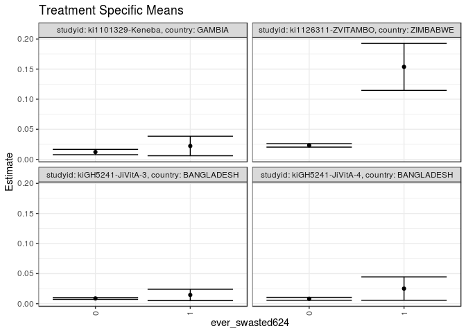

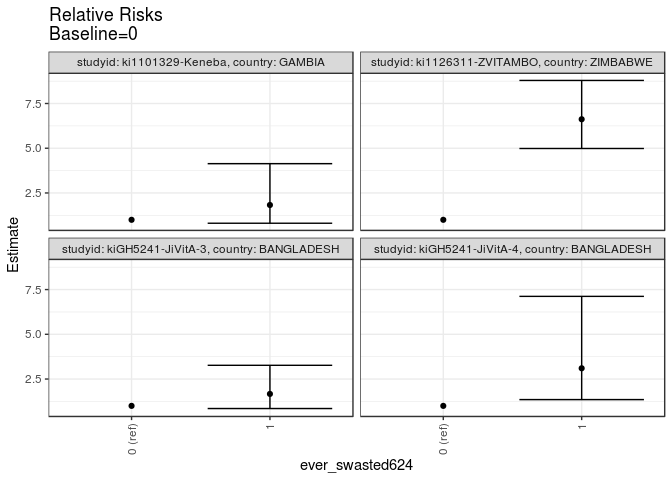

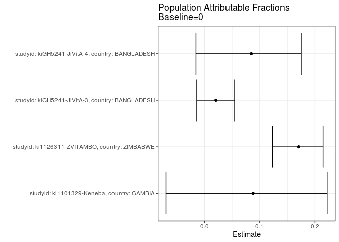

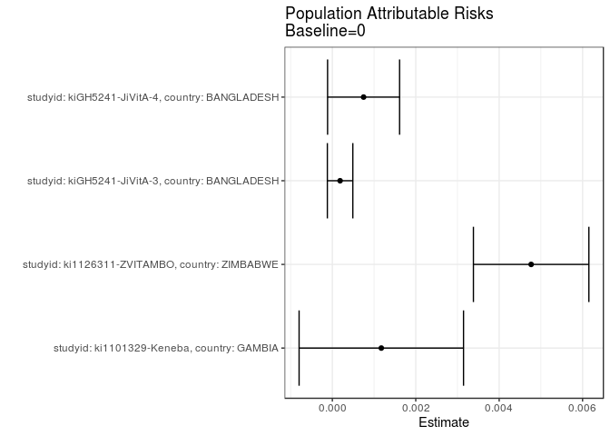

## Results Table

### Parameter: TSM

| studyid | country | intervention_level | baseline_level | estimate | ci_lower | ci_upper |
| --- | --- | --- | --- | --- | --- | --- |
| ki1101329-Keneba | GAMBIA | 0 | NA | 0.0121593 | 0.0077600 | 0.0165586 |
| ki1101329-Keneba | GAMBIA | 1 | NA | 0.0222222 | 0.0059410 | 0.0385034 |
| ki1126311-ZVITAMBO | ZIMBABWE | 0 | NA | 0.0232217 | 0.0203203 | 0.0261232 |
| ki1126311-ZVITAMBO | ZIMBABWE | 1 | NA | 0.1537263 | 0.1146056 | 0.1928471 |
| kiGH5241-JiVitA-3 | BANGLADESH | 0 | NA | 0.0087341 | 0.0072783 | 0.0101900 |
| kiGH5241-JiVitA-3 | BANGLADESH | 1 | NA | 0.0145719 | 0.0051221 | 0.0240218 |
| kiGH5241-JiVitA-4 | BANGLADESH | 0 | NA | 0.0080940 | 0.0056069 | 0.0105812 |
| kiGH5241-JiVitA-4 | BANGLADESH | 1 | NA | 0.0251046 | 0.0056051 | 0.0446041 |

### Parameter: E(Y)

| studyid | country | intervention_level | baseline_level | estimate | ci_lower | ci_upper |
| --- | --- | --- | --- | --- | --- | --- |
| ki1101329-Keneba | GAMBIA | NA | NA | 0.0133333 | 0.0090062 | 0.0176605 |
| ki1126311-ZVITAMBO | ZIMBABWE | NA | NA | 0.0279884 | 0.0248605 | 0.0311162 |
| kiGH5241-JiVitA-3 | BANGLADESH | NA | NA | 0.0089198 | 0.0074837 | 0.0103559 |
| kiGH5241-JiVitA-4 | BANGLADESH | NA | NA | 0.0088430 | 0.0063037 | 0.0113823 |

### Parameter: RR

| studyid | country | intervention_level | baseline_level | estimate | ci_lower | ci_upper |
| --- | --- | --- | --- | --- | --- | --- |
| ki1101329-Keneba | GAMBIA | 0 | 0 | 1.000000 | 1.0000000 | 1.000000 |
| ki1101329-Keneba | GAMBIA | 1 | 0 | 1.827586 | 0.8072482 | 4.137602 |
| ki1126311-ZVITAMBO | ZIMBABWE | 0 | 0 | 1.000000 | 1.0000000 | 1.000000 |
| ki1126311-ZVITAMBO | ZIMBABWE | 1 | 0 | 6.619930 | 4.9862794 | 8.788812 |
| kiGH5241-JiVitA-3 | BANGLADESH | 0 | 0 | 1.000000 | 1.0000000 | 1.000000 |
| kiGH5241-JiVitA-3 | BANGLADESH | 1 | 0 | 1.668388 | 0.8516652 | 3.268326 |
| kiGH5241-JiVitA-4 | BANGLADESH | 0 | 0 | 1.000000 | 1.0000000 | 1.000000 |
| kiGH5241-JiVitA-4 | BANGLADESH | 1 | 0 | 3.101614 | 1.3507520 | 7.121965 |

### Parameter: PAR

| studyid | country | intervention_level | baseline_level | estimate | ci_lower | ci_upper |
| --- | --- | --- | --- | --- | --- | --- |
| ki1101329-Keneba | GAMBIA | 0 | NA | 0.0011740 | -0.0007974 | 0.0031454 |
| ki1126311-ZVITAMBO | ZIMBABWE | 0 | NA | 0.0047666 | 0.0033825 | 0.0061508 |
| kiGH5241-JiVitA-3 | BANGLADESH | 0 | NA | 0.0001856 | -0.0001197 | 0.0004910 |
| kiGH5241-JiVitA-4 | BANGLADESH | 0 | NA | 0.0007490 | -0.0001144 | 0.0016124 |

### Parameter: PAF

| studyid | country | intervention_level | baseline_level | estimate | ci_lower | ci_upper |
| --- | --- | --- | --- | --- | --- | --- |
| ki1101329-Keneba | GAMBIA | 0 | NA | 0.0880503 | -0.0692706 | 0.2222247 |
| ki1126311-ZVITAMBO | ZIMBABWE | 0 | NA | 0.1703080 | 0.1232535 | 0.2148371 |
| kiGH5241-JiVitA-3 | BANGLADESH | 0 | NA | 0.0208114 | -0.0140563 | 0.0544802 |
| kiGH5241-JiVitA-4 | BANGLADESH | 0 | NA | 0.0846984 | -0.0154515 | 0.1749709 |